# Interpretation of Data 2 Aviation Data Analysis

Katie Thunder

A00304095

04-11-2023

## Introduction

This report will explore, clean, and analyse U.S. flight data. Various functions will be employed to enhance our understanding of the data. Then the data will be cleaned by removing rows with NA values and removing irrelevant columns. The report will explore which airlines have the most delays, identify the busiest flight routes, investigate the relationship between airport distances and flight duration, and apply a simple linear regression model to estimate flying times based on travel distances. The report will use a variety of graphs and plots to visually present the findings.

## Data Understanding and Cleaning

The first step is reading in the csv files:

```r
# Read in csv files
airlines <- read.csv("../Data/US_airlines.csv")
airports <- read.csv("../Data/US_airports.csv")
airrecords <- read.csv("../Data/US_airrecords14.csv")
```

Various functions were used on each dataset to understand the structure of the data. `Str()` provides information on the structure of the data. `Head()` shows the first 10 rows and `Summary()` provides summary statistics.

From these initial checks, it was observed that there are some **NA** values in the airrecords data that need further investigation. Specifically in the `ELAPSED_TIME` and `AIR_TIME` columns.

The total number of cancelled and diverted flights was 3119 which is the same as the number of missing rows. Once the rows with missing **NA** values were identified, unnecessary columns were removed from the airrecords dataset to create a subset of airrecords.

```r
# Subset airrecords by removing some columns
subset_airrecords <- airrecords %>%
  select(-YEAR, -MONTH, -DAY, -DAY_OF_WEEK, -FLIGHT_NUMBER, -TAIL_NUMBER)
```

```r
# Filter out cancelled and diverted flights for clean subset
subset_airrecords_clean <- subset_airrecords %>% filter(CANCELLED == 0, DIVERTED == 0)
```

The final subset only contains the first 17 columns as columns 17 - 25 had too many **NA** values and would not contribute to the analysis.

```r
# Select the first 17 columns from the cleaned subset
final_subset_airrecords <- subset_airrecords_clean %>% select(1:17)
```

## Identifying the Airlines that experience the most delays

The airrecords dataset did not include the name of the airlines, which will be useful for visualising the results. It was necessary to merge the airlines dataset with the airrecords dataset so that the airline names are included in the airrecords dataset. The result is a new column created in the `final_subset_airrecords` data frame called `AIRLINE_NAME` that includes the airline names from the airlines dataset.

Next, it was necessary to calculate the airlines with the most delays. This was achieved using the following code:

```r
# Count delays for each airline
delay_counts <- final_subset_airrecords %>%
  group_by(AIRLINE_NAME) %>%
  summarise(Num_Delays = sum(DEPARTURE_DELAY > 0 | ARRIVAL_DELAY > 0, na.rm = TRUE)) %>%
  arrange(desc(Num_Delays))
```

The results were visualised using a barchart. Bar charts are ideal for displaying categorical data, as they clearly illustrate comparisons across different categories.

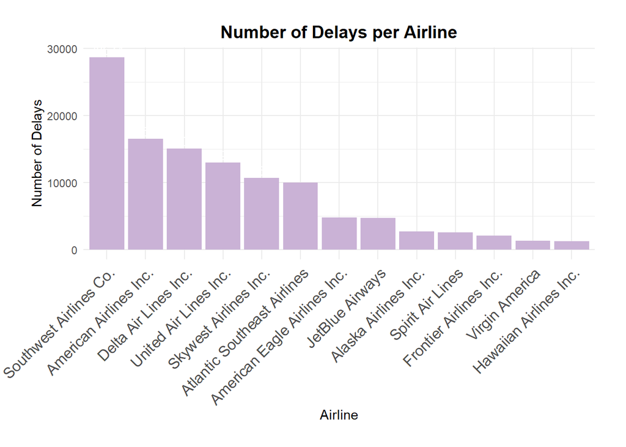

Figure 1. Barplot showing number of delays per Airline

## Identifying the busiest routes

This code finds the busiest route:

```r
# Group by origin and destination airports, count the number of flights for each route, and then arranging the results in descending order by the count of flights.
route_data <- final_subset_airrecords %>%
  group_by(`ORIGIN_AIRPORT`, `DESTINATION_AIRPORT`) %>%
  summarise(Num_Flights = n()) %>%
  arrange(desc(Num_Flights))
```

It was necessary to merge route data with airport details for both origin and destination airports and rename the resulting airport name columns for clarity. Routes dataframe will now contain origin and destination airport location details including co-ordinates and ordered by highest number of flights. This can be used to plot the map to visualise the busiest routes.

```r
# Merge route data with airport details for both origin and destination airports
routes <- route_data %>%
  left_join(airports, by = c("ORIGIN_AIRPORT" = "IATA_CODE")) %>%
  left_join(airports, by = c("DESTINATION_AIRPORT" = "IATA_CODE"))

routes <- routes %>%
  rename(
    ORIGIN_AIRPORT_FN = AIRPORT.x,
    DESTINATION_AIRPORT_FN = AIRPORT.y
  )
```

BBOX finder was used to find the co-ordinates for USA and they were stored in the stadia_USA variable.

Variables were created to store the points and lines data that will be used to plot the map. The map would be far too busy if all the points were included, so only the top 10 busiest routes were plotted. This was achieved by using the head function when storing both `points_data` and `lines_data`.

```r
# Select the first 10 rows for points - using unique airports
points_data <- head(routes, 10) %>%
  select(AIRPORT_ID = ORIGIN_AIRPORT, Lon = LONGITUDE.x, Lat = LATITUDE.x) %>%
  distinct()

# Select the first 10 rows for lines - including start and end coordinates
lines_data <- head(routes, 10) %>%
  select(Num_Flights,
         StartLon = LONGITUDE.x, StartLat = LATITUDE.x,
         EndLon = LONGITUDE.y, EndLat = LATITUDE.y)
```

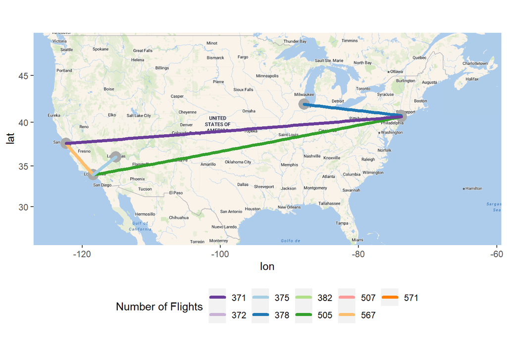

Figure 2. Map of U.S displaying top 10 busiest routes

The map shows the top 10 busiest routes. The colour of each line refers to the number of flights that can be identified by the legend underneath the map. For example, the dark green line goes from Los Angeles to New York and there were 505 flights.

## Examining the relationship between Distance and Flying Time

The `cor()` function was used to calculate the correlation coefficient between Distance and Flying Time.

```r
# Run cor() function to find strength of correlation between distance and airtime
correlation <- cor(final_subset_airrecords$DISTANCE, final_subset_airrecords$AIR_TIME)
```

The correlation coefficient for Distance and Airtime is 0.9914567. The correlation coefficient of 0.9914567 reflects a strong, positive linear relationship between Distance and Air time, indicating that they move together almost perfectly in proportion. As one variable increases, so does the other. A scatterplot was used to visualise the relationship as scatterplots are ideal for displaying the relationship between two variables.

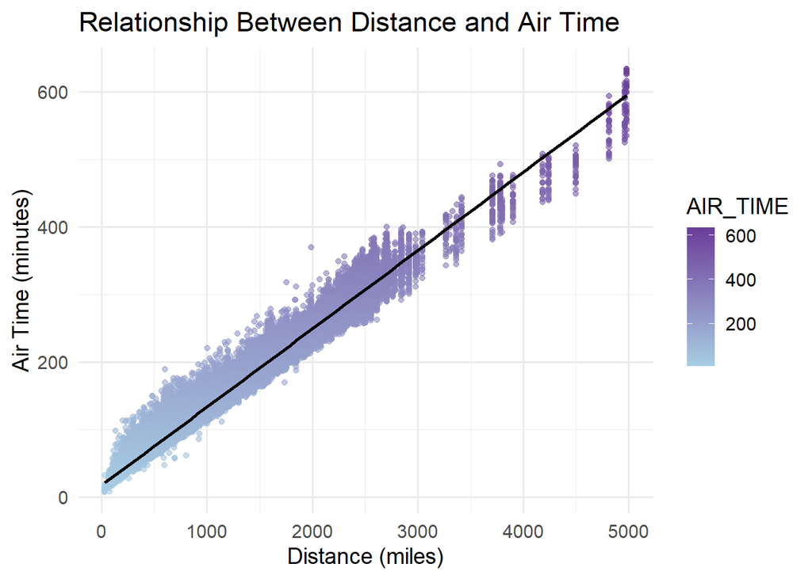

Figure.3 Scatterplot displaying the relationship between Distance and Air time

The scatterplot depicts the relationship between distance in miles and air time in minutes for the flights in the data. The data points are colour-coded based on air time, with a gradient ranging from light to dark purple for increasing flight duration. The trend in the data is highlighted by a best-fit line, suggesting a positive linear correlation: as the distance increases, the air time tends to increase as well. The concentration of darker shades along the line indicates that longer flights are consistently taking more time. There’s a visible pattern of increasing variance in air time for flights over longer distances, indicated by the spread of data points around the line of best fit, which could suggest that factors other than distance start to have a more significant impact on air time for longer flights.

## Predicting Flying Time based on Distance

A linear regression model was used to predict flying time based on distance. First, the data was split into train and test data. The training data was used for model training and then the model was tested on unseen test data to see how it performed at predicting air time.

```r
# Split the data into a training set and a test set
set.seed(123)  # For reproducibility

train_index <- sample(1:nrow(final_subset_airrecords), 0.8 * nrow(final_subset_airrecords))

train_data <- final_subset_airrecords[train_index, ]
test_data <- final_subset_airrecords[-train_index, ]
```

A linear regression model was trained using the lm function to predict `AIR_TIME` based on `DISTANCE` from the train data. Once the model was trained, the model was assessed using the `summary()` function.

```r
# Train the model
model <- lm(AIR_TIME ~ DISTANCE, data = train_data)

# Assess the model
summary(model)
```

```
##
## Call:
## lm(formula = AIR_TIME ~ DISTANCE, data = train_data)
##
## Residuals:
##     Min      1Q  Median      3Q     Max
## -90.110  -5.175  -1.074   4.143 121.141
##
## Coefficients:
##              Estimate Std. Error t value Pr(>|t|)
## (Intercept) 1.713e+01  3.750e-02   456.8   <2e-16 ***
## DISTANCE    1.159e-01  3.571e-05  3247.2   <2e-16 ***
## ---
## Signif. codes:  0 '***' 0.001 '**' 0.01 '*' 0.05 '.' 0.1 ' ' 1
##
## Residual standard error: 9.529 on 182785 degrees of freedom
## Multiple R-squared:  0.983,  Adjusted R-squared:  0.983
## F-statistic: 1.054e+07 on 1 and 182785 DF,  p-value: < 2.2e-16
```

This summary from an R linear regression output indicated a strong and statistically significant model where the independent variable `DISTANCE` was highly predictive of `AIR_TIME`. The model explained 98.3% of the variability in the data (R-squared = 0.983). The Residual Standard Error is 9.529, suggesting that the actual values deviated from the predicted values by this amount on average. The p-value was small enough to confirm the model’s predictions were not due to random chance.

After assessing the model, air time was predicted on a separate test data set. The differences between the actual air times in the test data set and the predicted air times from the model were computed as residuals. These residuals were then plotted against the predicted air times in a residual plot.

```r
# Test the model
predicted_air_time <- predict(model, newdata = test_data)

# Store the residuals
residuals <- test_data$AIR_TIME - predicted_air_time
```

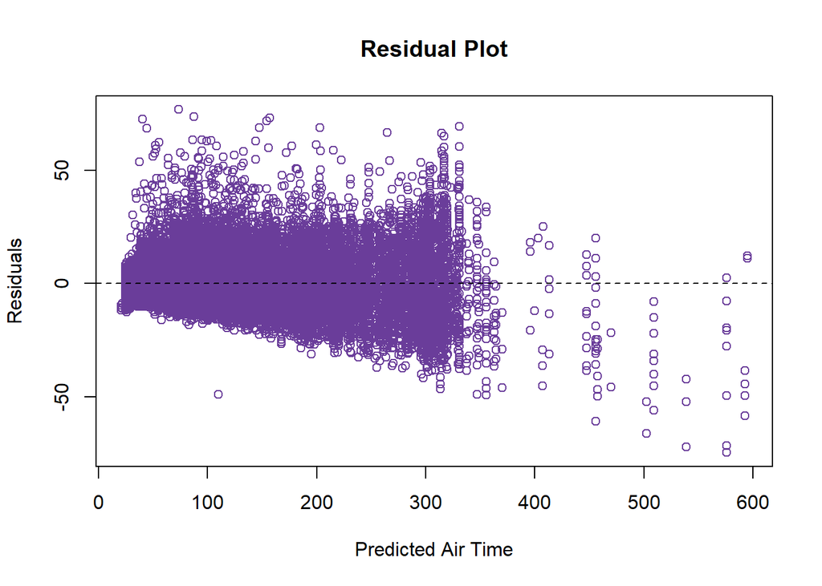

Figure.4 Scatterplot of Residuals Against Predicted Air Time

There seems to be a funnel shape with residuals fanning out as the predicted air time increases. The concentration of residuals near the zero line for lower predicted air times suggests that the model predicts air time more accurately for shorter flights. However, as the predicted air time increases, the residuals become more spread out, indicating less accurate predictions for longer flights.

Another way to assess the model is the Means Squared Error (MSE) and the Root Mean Squared Error (RMSE). The MSE calculates the average of the squared differences between the predicted values and the actual values, penalizing larger errors more severely. RMSE takes the square root of MSE, which adjusts the scale back to the original units of measurement. Both metrics give a numerical value that reflects the average distance between the predicted flight times and the actual flight times, with a lower value indicating better model performance.

```r
# Calculate the MSE and the RMSE
mse <- mean(residuals^2)
rmse <- sqrt(mse)
```

The MSE value is is 90.3048261. The RMSE value is 9.5028851. This indicates that the average prediction error of the model is about 9.5 minutes. For the purposes of this report, that is an acceptable error rate. However, if this was a situation that `AIR_TIME` prediction errors could have big impacts, like affecting schedules or costs, then a RMSE value of 9.5 may be too high.

## Conclusion

This report explored and analysed US flight data and uncovered some interesting findings. The findings included which airlines get delayed the most and which flight paths are the busiest. The report examined the relationship between distance and flying time and used linear regression to predict flying time based on distance. The report displayed the results with easy-to-understand charts and graphs, giving a clear picture of what’s going on with flights in the US.

## Reflection

I began this analysis by attempting to get a strong understanding of the data. This is the first time I’ve used three datasets in one project so it took a little longer than usual. Once I had discovered how the datasets were connected with each other, I felt more comfortable with the project. I took time to understand what variables I would need to answer each part of the project, and the variables I chose to keep and remove were based on that. I did however have to do more data manipulation and merging to answer certain parts of the project. An issue I faced was with the working directory, as my code and data are in two separate folders it was returning errors when trying to read in the data. However, I was able to overcome this and once the working directory is set to the project directory, the script files will run. The aspect of the project I struggled the most with was getting the map to work. I ran into several errors every time and when I came up with a workaround for one error, I would get another one. I found that I would not be able to get devtools and stadiamap to work if I tried to install the packages as a block of code. Instead, I ran each line individually and made sure to leave clear comments on the script file. Something I was unable to work around was the lines overlapping each other. I tried using the jitter() function but this was not suitable. I tried to find other solutions to add a bend to the lines but the bends were too drastic and made the lines come off the map. Despite this, I am pleased with how the map turned out in the end. Working with RMarkdown was a learning curve and it took time to get comfortable with using it. I aimed to make my report look cohesive by using complementary colours on my plots and graphs, I discovered a package called “RColorBrewer” that contains colours that complement each other. I think this worked out well and I am happy with how the results came out. I believe my analysis could have been improved if I used multiple linear regression instead of a simple linear regression model for prediction. More analysis could have been conducted to see if any other variables have an impact on predicting flight time, not just distance. Future work could include using more complex models such as ridge regression for prediction as this would minimise the impact of multicollinearity between variables and reduce overfitting on training data. This could lead to more accurate predictions.